# PSL: Tree-Based (Regression) Models

### Week 6 Example (Fall 2025)

This notebook is a Python conversion of the original R Markdown document, using `scikit-learn`, `pandas`, and `matplotlib`.

## 1. Setup and Data Loading

First, we import the necessary Python libraries for our analysis.

```python
import pandas as pd
import numpy as np
import matplotlib.pyplot as plt

# Scikit-learn modules
from sklearn.model_selection import GridSearchCV, train_test_split
from sklearn.tree import DecisionTreeRegressor, plot_tree
from sklearn.ensemble import RandomForestRegressor, GradientBoostingRegressor
from sklearn.metrics import mean_squared_error

plt.style.use('seaborn-v0_8-darkgrid')
```

The `whitewines.csv` data set contains information related to white variants of the Portuguese "Vinho Verde" wine.

Specifically, we have recorded the following information:

1. `fixed acidity`,
2. `volatile acidity`,
3. `citric acid` ,
4. `residual sugar`,
5. `chlorides` ,
6. `free sulfur dioxide`,
7. `total sulfur dioxide`,
8. `density`,
9. `pH`,
10. `sulphates`,
11. `alcohol`,
12. `quality` (score between 0 and 10)

The data set can be downloaded here: [whitewines.csv](https://archive.ics.uci.edu/dataset/186/wine+quality)

```python
whitewines = pd.read_csv('whitewines.csv', sep=';')

# The column names in the original file have spaces, which can be inconvenient.
# Let's replace spaces with underscores.
whitewines.columns = whitewines.columns.str.replace(' ', '_')

print("First 5 rows of the dataset:")
display(whitewines.head())

print(f"\nDataset dimensions (rows, columns): {whitewines.shape}")
```

```
First 5 rows of the dataset:
```

|  | fixed_acidity | volatile_acidity | citric_acid | residual_sugar | chlorides | free_sulfur_dioxide | total_sulfur_dioxide | density | pH | sulphates | alcohol | quality |
| --- | --- | --- | --- | --- | --- | --- | --- | --- | --- | --- | --- | --- |
| 0 | 7.0 | 0.27 | 0.36 | 20.7 | 0.045 | 45.0 | 170.0 | 1.0010 | 3.00 | 0.45 | 8.8 | 6 |
| 1 | 6.3 | 0.30 | 0.34 | 1.6 | 0.049 | 14.0 | 132.0 | 0.9940 | 3.30 | 0.49 | 9.5 | 6 |
| 2 | 8.1 | 0.28 | 0.40 | 6.9 | 0.050 | 30.0 | 97.0 | 0.9951 | 3.26 | 0.44 | 10.1 | 6 |
| 3 | 7.2 | 0.23 | 0.32 | 8.5 | 0.058 | 47.0 | 186.0 | 0.9956 | 3.19 | 0.40 | 9.9 | 6 |
| 4 | 7.2 | 0.23 | 0.32 | 8.5 | 0.058 | 47.0 | 186.0 | 0.9956 | 3.19 | 0.40 | 9.9 | 6 |

```
Dataset dimensions (rows, columns): (4898, 12)
```

## 2. Simple Regression Tree

In Python, the primary library for fitting tree models is `scikit-learn`. The `DecisionTreeRegressor` class is roughly equivalent to both R's `tree` and `rpart` packages for regression tasks.

### Fitting a Basic Tree

For illustration purposes, let's first focus on just two predictors: `alcohol` and `volatile_acidity` to predict `quality`.

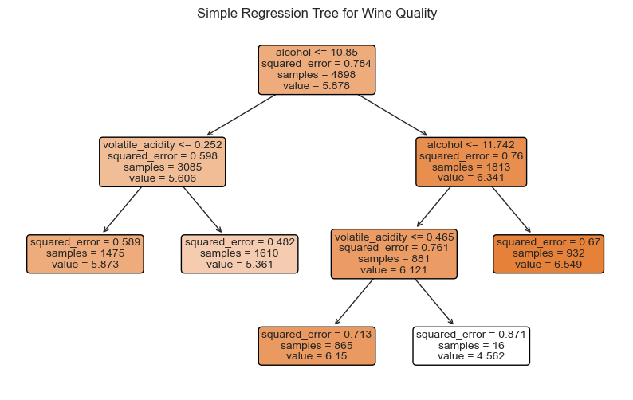

```python
feature_names = ['alcohol', 'volatile_acidity']
X_simple = whitewines[feature_names]
y = whitewines['quality']

# Fit the regression tree
# We adjust the parameters to replicate behavior of tree() in R
simple_tree = DecisionTreeRegressor(
    max_depth=3, min_impurity_decrease=0.008, random_state=598)
simple_tree.fit(X_simple, y)

# Plot the fitted tree model
plt.figure(figsize=(10, 6))
plot_tree(simple_tree,
          feature_names=X_simple.columns,
          filled=True,
          rounded=True,
          fontsize=10)
plt.title("Simple Regression Tree for Wine Quality")
plt.show()
```

### Visualizing Tree Partitions

We can create a scatter plot to visualize the rectangular regions created by the tree's splits. Unfortunately, scikit-learn does not provide a convenient helper function as R does. In the next cell, we will partially convert the `partition.tree()` function from the `tree` package to make the plot.

```python
from matplotlib.collections import LineCollection


def ptXlines(x, v, xrange, xcoord=None, ycoord=None, i=0):
    """
    Recursive helper to compute partition lines (translation of treemisc.R).
    See: https://rdrr.io/cran/tree/src/R/treemisc.R
    """
    if xcoord is None:
        xcoord = []
    if ycoord is None:
        ycoord = []

    # If leaf node: store center of rectangle
    if x[i] == -2:
        y1 = (xrange[0] + xrange[2]) / 2.0
        y2 = (xrange[1] + xrange[3]) / 2.0
        return xcoord, ycoord + [y1, y2], i

    # Split on first variable
    if v[i] == 0:
        xcoord = xcoord + [x[i], xrange[1], x[i], xrange[3]]

        xr = list(xrange)
        xr[2] = x[i]
        ll2 = ptXlines(x, v, xr, xcoord, ycoord, i + 1)

        xr = list(xrange)
        xr[0] = x[i]
        return ptXlines(x, v, xr, ll2[0], ll2[1], ll2[2] + 1)

    # Split on second variable
    elif v[i] == 1:
        xcoord = xcoord + [xrange[0], x[i], xrange[2], x[i]]

        xr = list(xrange)
        xr[3] = x[i]
        ll2 = ptXlines(x, v, xr, xcoord, ycoord, i + 1)

        xr = list(xrange)
        xr[1] = x[i]
        return ptXlines(x, v, xr, ll2[0], ll2[1], ll2[2] + 1)

    else:
        raise ValueError("wrong variable numbers in tree.")


def partition_tree(tree, data, ax=None, **kwargs):
    x = tree.tree_.threshold
    v = tree.tree_.feature
    is_leave = x == -2

    x_min, y_min = data.min().values
    x_max, y_max = data.max().values

    x_range = x_max - x_min
    y_range = y_max - y_min

    x_min -= 0.025 * x_range
    x_max += 0.025 * x_range
    y_min -= 0.025 * y_range
    y_max += 0.025 * y_range

    xrange = np.array([x_min, y_min, x_max, y_max])
    xcoord, ycoord, _ = ptXlines(x, v, xrange, None, None)
    var_names = simple_tree.feature_names_in_

    # plot
    if ax is None:
        _, ax = plt.subplots()

    ax.scatter(x=data.iloc[:, 0], y=data.iloc[:, 1], c=data.iloc[:, 1],
               **kwargs)
    ax.set_xlabel(var_names[0])
    ax.set_ylabel(var_names[1])
    ax.legend([], [], frameon=False)

    # build segments as [[(x0,y0), (x1,y1)], ...]
    segments = [[xcoord[i:(i + 2)], xcoord[(i + 2):(i + 4)]]
                for i in range(0, len(xcoord), 4)]

    lc = LineCollection(segments, colors='k')  # black lines by default

    # add labels
    yy = np.array(ycoord).reshape((2, -1), order="F")
    label_val = np.round(tree.tree_.value[is_leave].ravel(), 2)
    for i, txt in enumerate(label_val):
        ax.annotate(txt, (yy[0, i], yy[1, i]),
                    fontsize=14, ha='center', va='center')

    ax.add_collection(lc)
    ax.autoscale()

    return ax
```

Now we can create the rectangular regions (as in the lecture):

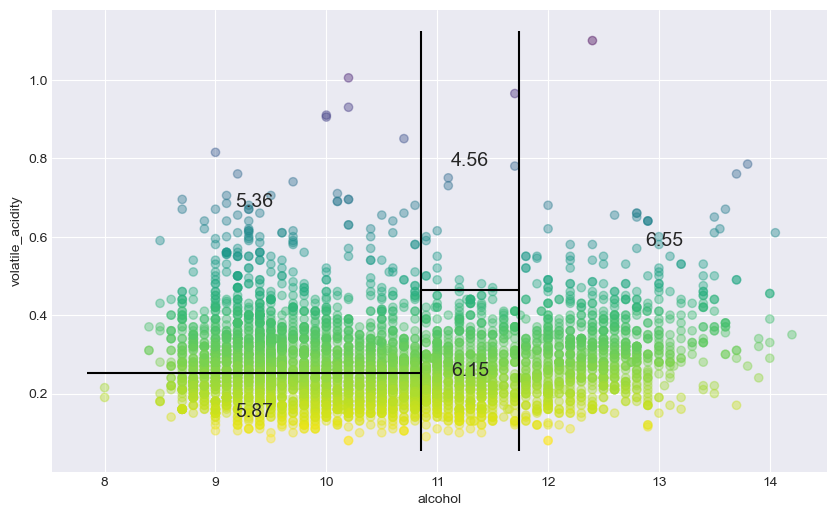

```python
fig, ax = plt.subplots(figsize=(10, 6))
partition_tree(simple_tree, X_simple, ax, cmap='viridis_r', alpha=0.4);
```

## 3. Pruning with Cost-Complexity

Now, we'll use all predictors. In `scikit-learn`, pruning is not done after fitting by default. Instead, we use **Cost-Complexity Pruning (CCP)**, which is very similar to the process used in `rpart`. The key tuning parameter is `ccp_alpha`, which is analogous to `CP` in R.

A `ccp_alpha > 0` will penalize the tree for having more nodes, effectively pruning it.

### Fitting a Full Tree

First, we fit a decision tree using all available predictors.

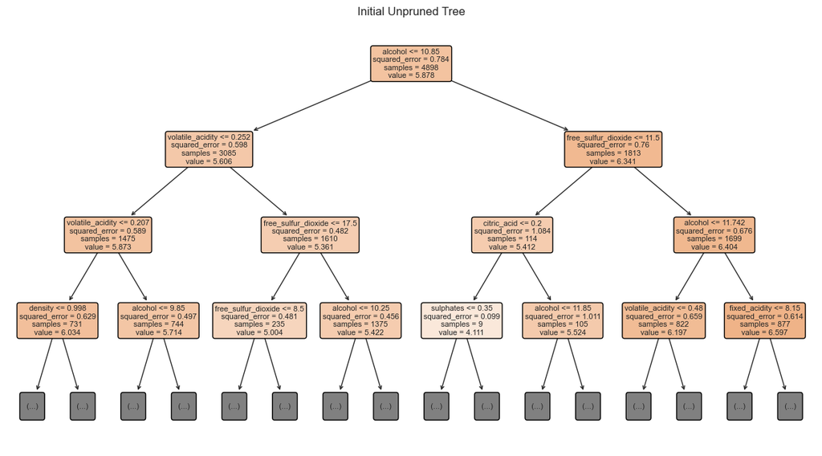

```python
X = whitewines.drop('quality', axis=1)
y = whitewines['quality']

wine_tree1 = DecisionTreeRegressor(random_state=598)
wine_tree1.fit(X, y)

# Visualize the (potentially very large) tree
plt.figure(figsize=(15, 8))
rpart_plot = plot_tree(wine_tree1, max_depth=3,
                       feature_names=X.columns, filled=True, rounded=True, fontsize=8)
plt.title("Initial Unpruned Tree")
plt.show()
```

### Understanding the Fitted Tree

Starting at the root node (top), the average `quality` for all observations is **5.878**. The *first split* occurs based on the variable `alcohol`. The left node contains samples with `alcohol <= 10.85` and has an average quality of **5.606**, while the right node contains the rest and has an average quality of **6.341**. Color shading of the nodes indicates the magnitude of their predictions.

### Cross-Validation

To find the optimal `ccp_alpha`, we first get the list of all possible effective $\alpha$ using `cost_complexity_pruning_path`. Then, we use cross-validation to find which alpha gives us the best out-of-sample performance.

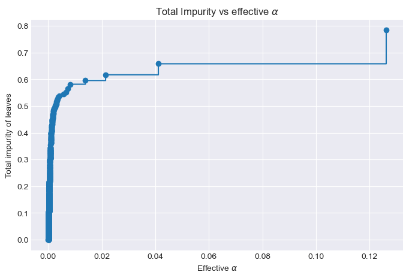

```python
path = wine_tree1.cost_complexity_pruning_path(X, y)
ccp_alphas, impurities = path.ccp_alphas, path.impurities

plt.figure(figsize=(8, 5))
plt.plot(ccp_alphas, impurities, marker="o", drawstyle="steps-post")
plt.xlabel("Effective $\\alpha$")
plt.ylabel("Total impurity of leaves")
plt.title("Total Impurity vs effective $\\alpha$");
```